# Exercises Day 1 Part 2

Bhavya Kaushik

## Load the data

Question: Load the gapminder dataset.

I am using the read_csv function from readr package to read my data.

```r
library(readr)
gapminder <- read_csv(here::here("data", "gapminder5.csv"))
head(gapminder, n = 5)
```

```
## # A tibble: 5 x 6
##   country      year      pop continent lifeExp gdpPercap
##   <chr>       <dbl>    <dbl> <chr>       <dbl>     <dbl>
## 1 Afghanistan  1952  8425333 Asia         28.8      779.
## 2 Afghanistan  1957  9240934 Asia         30.3      821.
## 3 Afghanistan  1962 10267083 Asia         32.0      853.
## 4 Afghanistan  1967 11537966 Asia         34.0      836.
## 5 Afghanistan  1972 13079460 Asia         36.1      740.
```

## If Statement

Question: Use an if() statement to print a suitable message reporting whether there are any records from 2002 in the gapminder dataset.

Hint: use the `any` function.

```r
year<-2002
if(any(gapminder$year == year)){
   print(paste("Record(s) for the year",year,"found."))
} else {
  print(paste("No records for year",year))
}
```

```
## [1] "Record(s) for the year 2002 found."
```

Now do the same for 2012.

```r
year<-2012
if(any(gapminder$year == year)){
   print(paste("Record(s) for the year",year,"found."))
} else {
  print(paste("No records for year",year))
}
```

```
## [1] "No records for year 2012"
```

## Loop and If Statements

Question: Write a script that finds the mean life expectancy by country for countries whose population is below the mean for the dataset

```r
overall_mean = mean(gapminder$pop)
for (i in unique(gapminder$country)) {
   country_mean = mean(gapminder$pop[gapminder$country==i])

   if (country_mean < overall_mean) {
     mean_le = mean(gapminder$lifeExp[gapminder$country==i])
     print(paste("Mean Life Expectancy in", i, "is", mean_le))
   }
} # end for loop
```

```
## [1] "Mean Life Expectancy in Afghanistan is 37.4788333333333"
## [1] "Mean Life Expectancy in Albania is 68.4329166666667"
## [1] "Mean Life Expectancy in Algeria is 59.0301666666667"
## [1] "Mean Life Expectancy in Angola is 37.8835"
## [1] "Mean Life Expectancy in Argentina is 69.0604166666667"
## [1] "Mean Life Expectancy in Australia is 74.6629166666667"
## [1] "Mean Life Expectancy in Austria is 73.10325"
## [1] "Mean Life Expectancy in Bahrain is 65.6056666666667"
## [1] "Mean Life Expectancy in Belgium is 73.64175"
## [1] "Mean Life Expectancy in Benin is 48.7799166666667"
## [1] "Mean Life Expectancy in Bolivia is 52.5045833333333"
## [1] "Mean Life Expectancy in Bosnia and Herzegovina is 67.7078333333333"
## [1] "Mean Life Expectancy in Botswana is 54.5975"
## [1] "Mean Life Expectancy in Bulgaria is 69.74375"
## [1] "Mean Life Expectancy in Burkina Faso is 44.694"
```

[output cut: 100 more lines]

Question: Write a script that loops through the `gapminder` data by continent and prints out whether the mean life expectancy is smaller than 50, between 50 and 70, or greater than 70.

```r
lower_threshold <- 50
upper_threshold <- 70

for (i in unique(gapminder$continent)){
    tmp <- mean(gapminder$lifeExp[gapminder$continent==i])

    if (tmp < lower_threshold){
        print(paste("Average Life Expectancy in", i, "is less than", lower_threshold))
    }
    else if (tmp > lower_threshold & tmp < upper_threshold){
        print(paste("Average Life Expectancy in", i, "is between", lower_threshold, "and", upper_threshold))
    }
    else {
        print(paste("Average Life Expectancy in", i, "is greater than", upper_threshold))
    }

}
```

```
## [1] "Average Life Expectancy in Asia is between 50 and 70"
## [1] "Average Life Expectancy in Europe is greater than 70"
## [1] "Average Life Expectancy in Africa is less than 50"
## [1] "Average Life Expectancy in Americas is between 50 and 70"
## [1] "Average Life Expectancy in Oceania is greater than 70"
```

## Writing Functions

Create a function that given a data frame will print the name of each column and the class of data it contains. Use the gapminder dataset. Hint: Use `mode()` or `class()` to get the class of the data in each column. Remember that `names()` or `colnames()` returns the name of the columns in a dataset.

```r
data_frame_info <- function(df) {
  cols <- names(df)
  for (i in cols) {
    print(paste0(i, ": ", mode(df[, i])))
  }
}
data_frame_info(gapminder)
```

```
## [1] "country: list"
## [1] "year: list"
## [1] "pop: list"
## [1] "continent: list"
## [1] "lifeExp: list"
## [1] "gdpPercap: list"
```

Create a function that given a vector will print the mean and the standard deviation of a **vector**, it will optionally also print the median. Hint: include an argument that takes a boolean (`TRUE`/`FALSE`) operator and then include an `if` statement.

```r
vector_info <- function(x, include_median=FALSE) {
  print(paste("Mean:", mean(x)))
  print(paste("Standard Deviation:", sd(x)))
  if (include_median) {
    print(paste("Median:", median(x)))
  }
}

le <- gapminder$lifeExp
vector_info(le, include_median = F)
```

```
## [1] "Mean: 59.4744393661972"
## [1] "Standard Deviation: 12.9171074152412"
```

```r
vector_info(le, include_median = T)
```

```
## [1] "Mean: 59.4744393661972"
## [1] "Standard Deviation: 12.9171074152412"
## [1] "Median: 60.7125"
```

## Analyzing the relationship between GDP per capita and life expectancy

Use what you’ve learned so far to answer the following questions using the `gapminder` dataset. Be sure to include some visualizations!

#### Question 1. What is the relationship between GDP per capita and life expectancy? Does this relationship change over time? (Hint: Use the natural log of both variables.)

```r
# Write a function to plot the linear natural log-log model relating GDP per capita to life expectancy
viz_lm <-
    function(df, dv, iv, year) {
        dat <- df[df[["year"]] == year, ]
        y <- log(dat[[dv]])
        x <- log(dat[[iv]])
        fit <- lm(y ~ x)
        plot(y ~ x, main = year,
             xlab = "log(lifeExp)", ylab = "log(gdpPercap)")
        lines(x, predict(fit), col = 'blue')
        print(paste("intercept obtained after fitting linear model =", coef(fit)[1]))
        print(paste("slope obtained after fitting linear model =", coef(fit)[2]))
    }
```

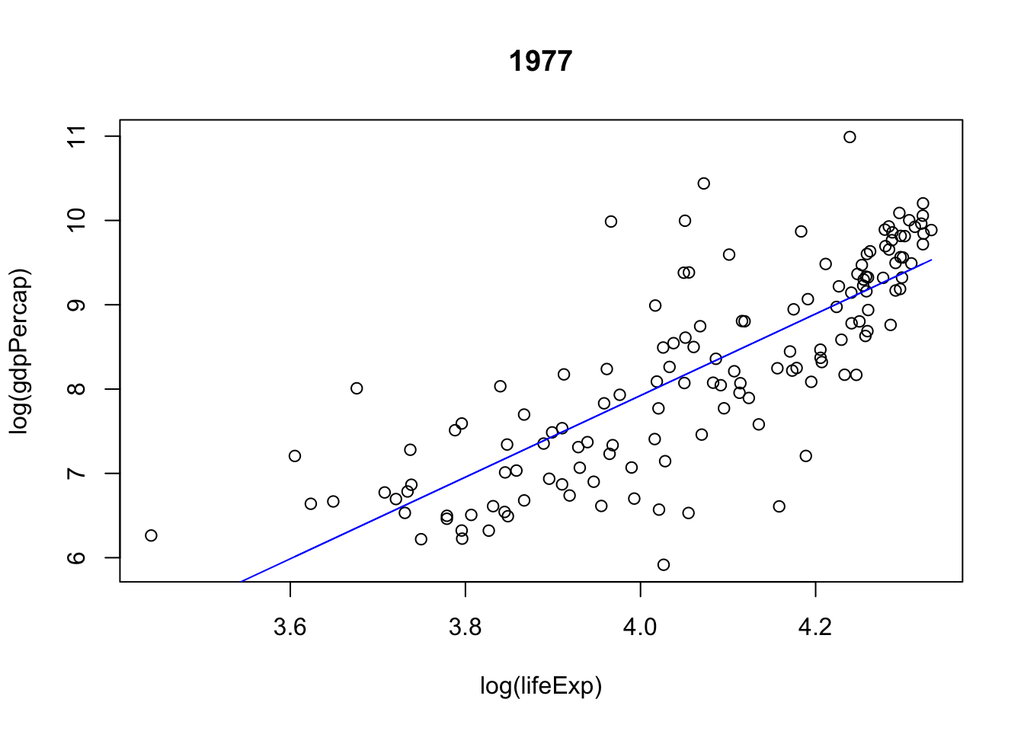

```
## [1] "intercept obtained after fitting linear model = -11.4419595836944"
## [1] "slope obtained after fitting linear model = 4.84149148837908"
```

```r
# Make a graph:
viz_lm(gapminder, "gdpPercap", "lifeExp", 1977)
```

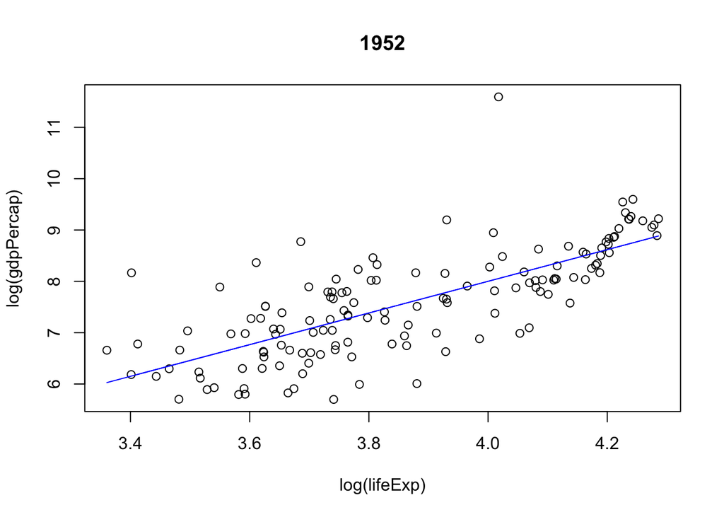

```
## [1] "intercept obtained after fitting linear model = -4.34129439475644"
## [1] "slope obtained after fitting linear model = 3.08570582170182"
```

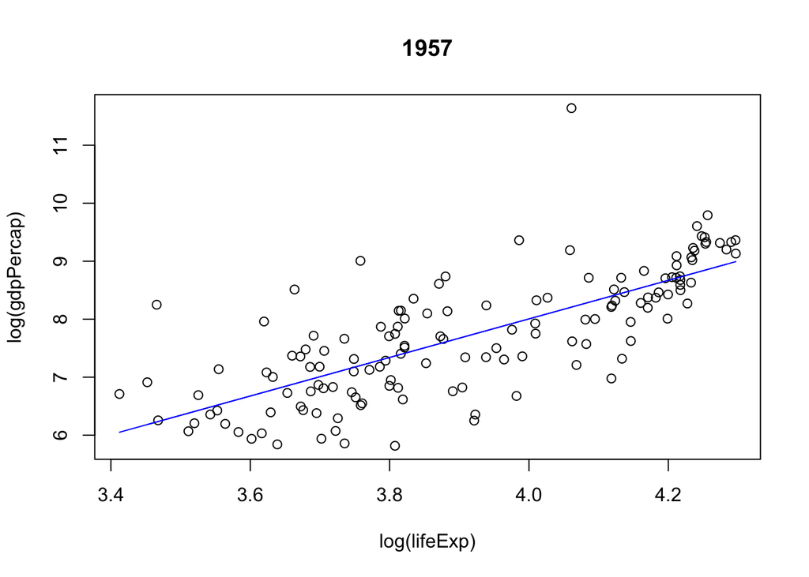

```
## [1] "intercept obtained after fitting linear model = -5.29773280922023"
## [1] "slope obtained after fitting linear model = 3.32583060720487"
```

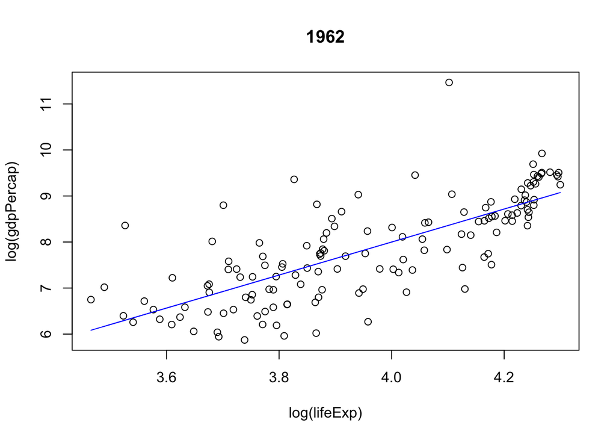

```
## [1] "intercept obtained after fitting linear model = -6.34541822347547"
## [1] "slope obtained after fitting linear model = 3.58631339726372"
```

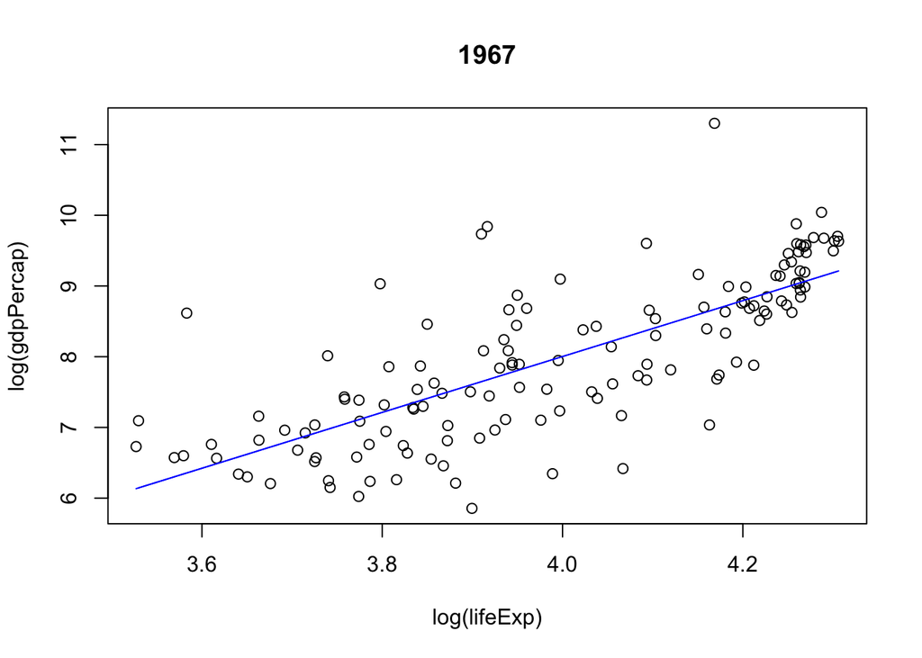

```
## [1] "intercept obtained after fitting linear model = -7.80233934888887"
## [1] "slope obtained after fitting linear model = 3.95133502280198"
```

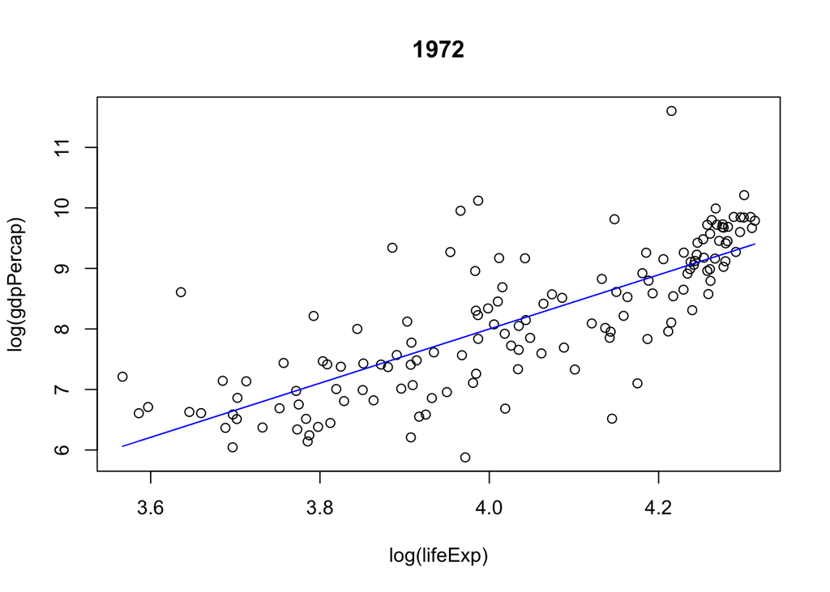

```
## [1] "intercept obtained after fitting linear model = -9.90090806541575"
## [1] "slope obtained after fitting linear model = 4.47506637959166"
```

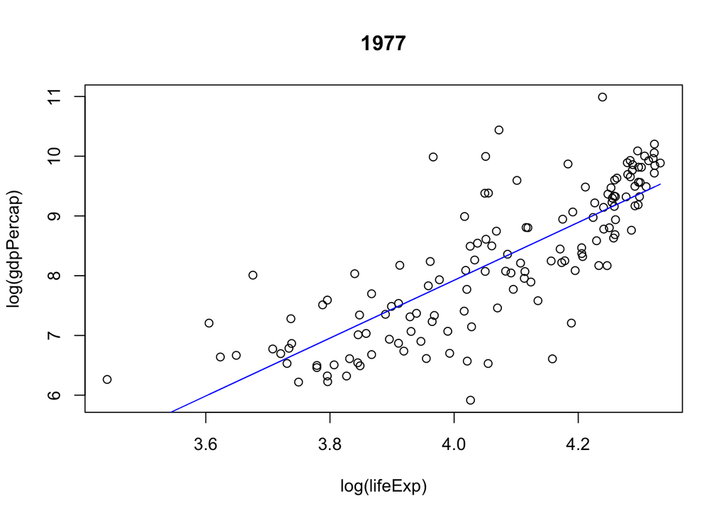

```
## [1] "intercept obtained after fitting linear model = -11.4419595836944"
## [1] "slope obtained after fitting linear model = 4.84149148837908"
```

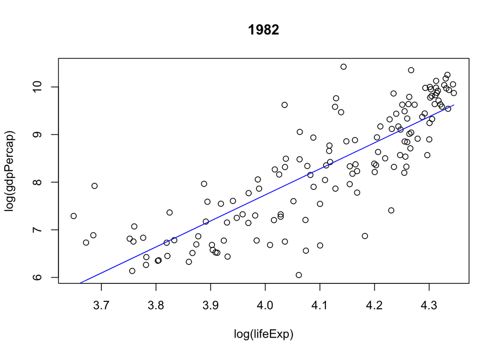

```
## [1] "intercept obtained after fitting linear model = -14.1423496805007"
## [1] "slope obtained after fitting linear model = 5.46901694228169"
```

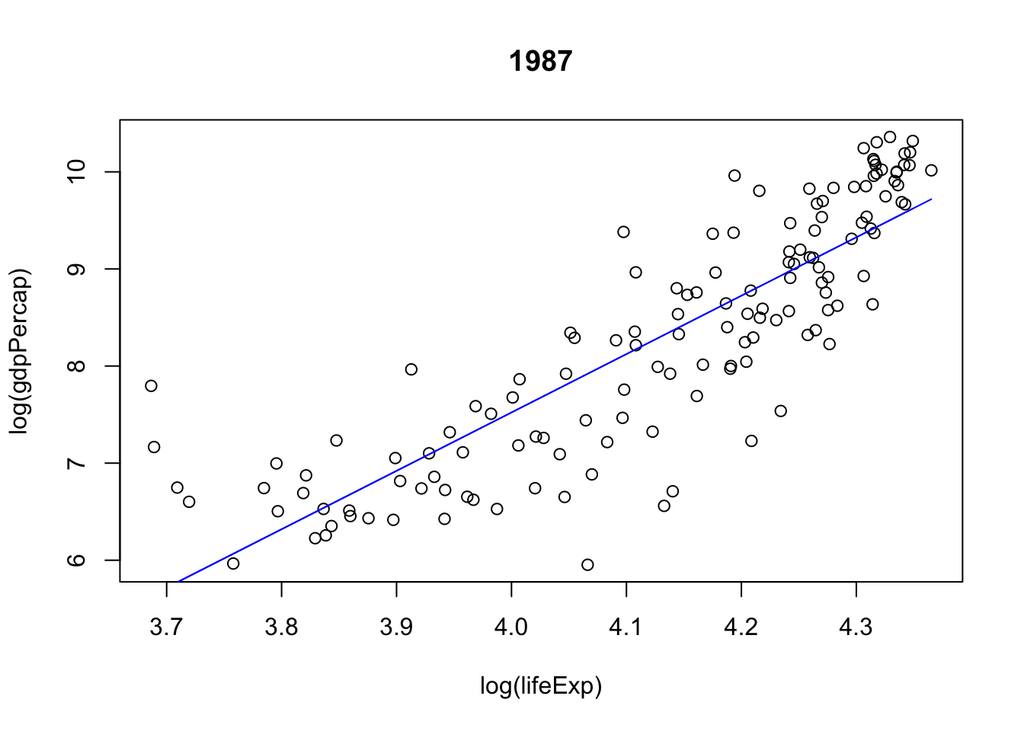

```
## [1] "intercept obtained after fitting linear model = -16.5330072308691"
## [1] "slope obtained after fitting linear model = 6.01377874497621"
```

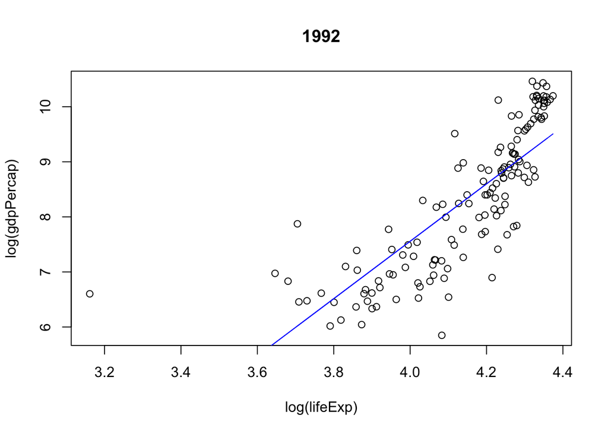

```
## [1] "intercept obtained after fitting linear model = -13.2952492758866"
## [1] "slope obtained after fitting linear model = 5.21307054297895"
```

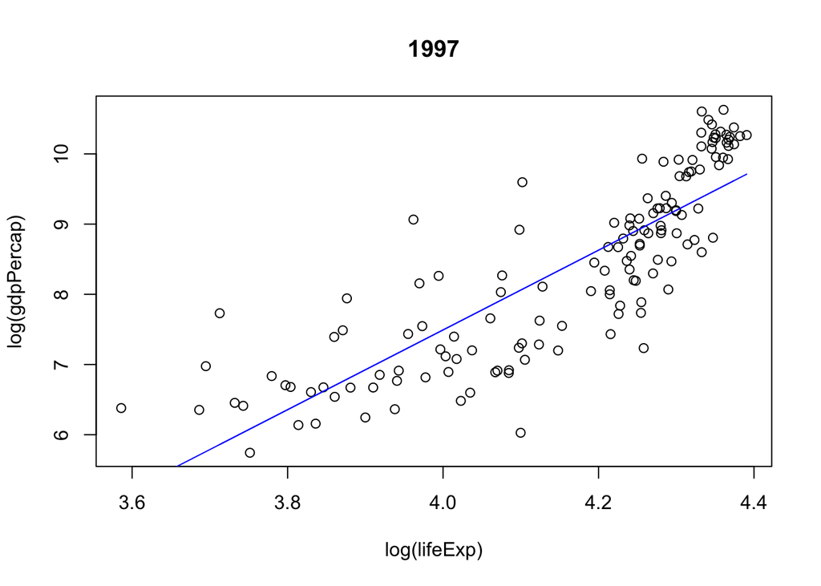

```
## [1] "intercept obtained after fitting linear model = -15.2289339620478"
## [1] "slope obtained after fitting linear model = 5.68052344729224"
```

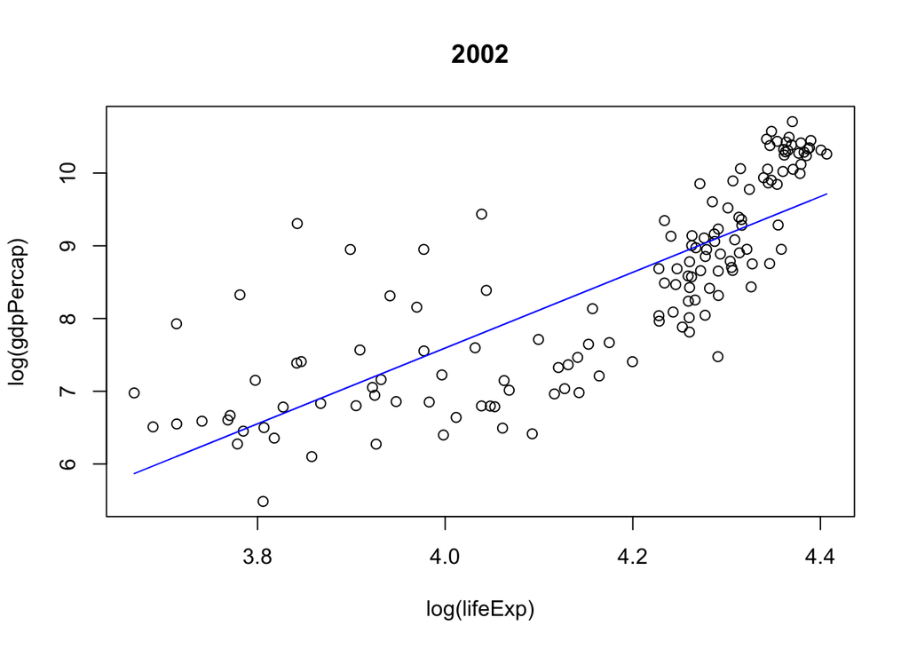

```
## [1] "intercept obtained after fitting linear model = -13.2378266912976"
## [1] "slope obtained after fitting linear model = 5.20802400211468"
```

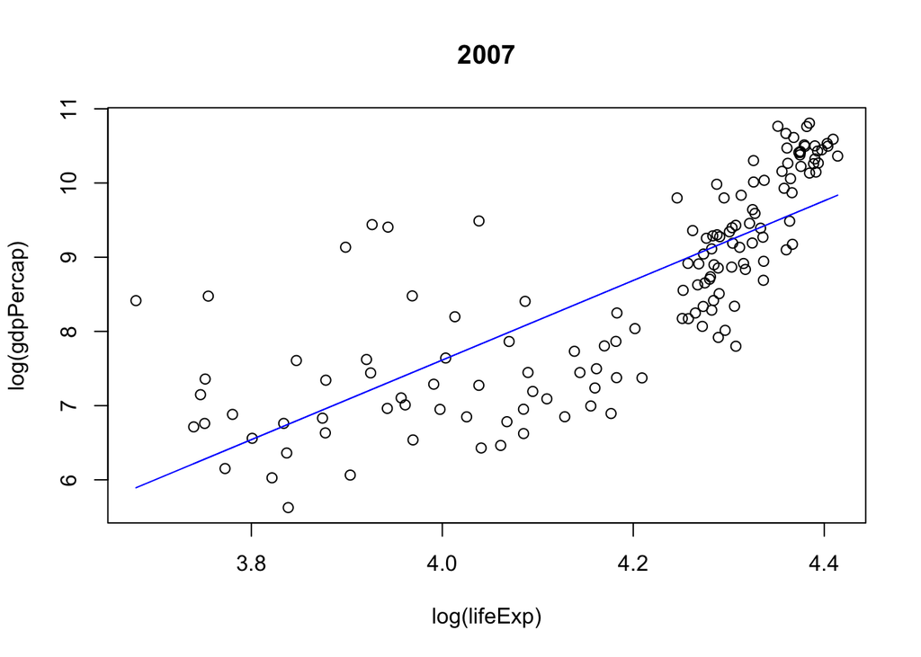

```
## [1] "intercept obtained after fitting linear model = -13.8441912456631"
## [1] "slope obtained after fitting linear model = 5.36466602370971"
```

```r
# loop it
years = unique(gapminder$year)
for (i in years) {
    viz_lm(gapminder, "gdpPercap", "lifeExp", i)
}
```